# Visualizations

2023-03-07

```r
library(tidyverse)
library(CalledStrike)
library(knitr)
library(kableExtra)
library(baseballr)
```

These are not all of the graphs, there are some in the original files for each of the games. Here are the links to the [OAK v. TOR](https://htmlpreview.github.io/?https://github.com/jajovanovic/SABR_Case/blob/main/OAK_v_TOR.html) game and the [TEX v. MIA](https://htmlpreview.github.io/?https://github.com/jajovanovic/SABR_Case/blob/main/TEX_v_MIA.html) game.

## OAK v. TOR

### Win / Loss

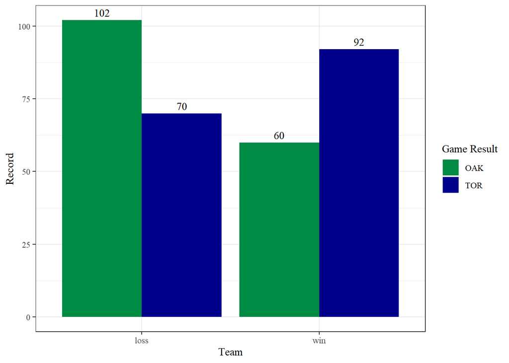

```r
win_loss_ot <- data.frame(team = c("OAK", "OAK", "TOR", "TOR"),
                       record = c(60, 102, 92, 70),
                       result = c("win", "loss", "win", "loss"),
                       season = c(2022, 2022, 2022, 2022))

win_loss_ot %>%
  group_by(team) %>%
  ggplot(aes(x = factor(result), y = record, fill = team)) +
  geom_col(position = "dodge") +
  geom_text(aes(label = record), vjust = -.5, position = position_dodge(.9), family = "serif") +
  labs(x = "Team", y = "Record", fill = "Game Result") +
  #ylim(0, 110) +
  theme_bw() +
  scale_fill_manual(values = c("springgreen4", "darkblue")) +
  theme(text=element_text(family = "serif"))
```

### Payroll

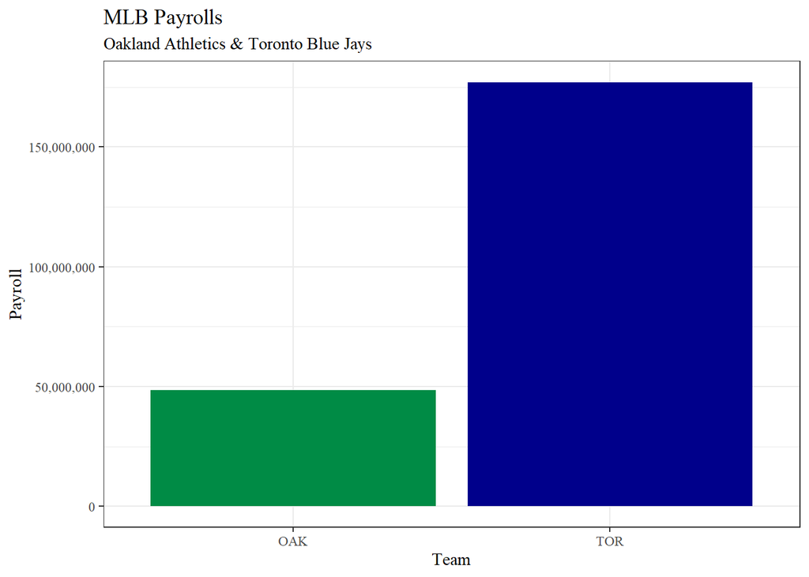

```r
payroll_ot <- data.frame(team = c("OAK", "TOR"),
                      season = c(2022, 2022),
                      payroll = c(48443900, 177071670))

payroll_ot %>%
  ggplot(aes(x = factor(team), y = payroll, fill = team)) +
  geom_col(position = "dodge") +
  labs(title = "MLB Payrolls", subtitle = "Oakland Athletics & Toronto Blue Jays",
       x = "Team", y = "Payroll") +
  theme_bw() +
  scale_y_continuous(labels = scales::comma) +
  scale_fill_manual(values = c("springgreen4", "darkblue")) +
  theme(text=element_text(family = "serif")) +
  theme(legend.position = "false")
```

## TEX v. MIA

### Win / Loss

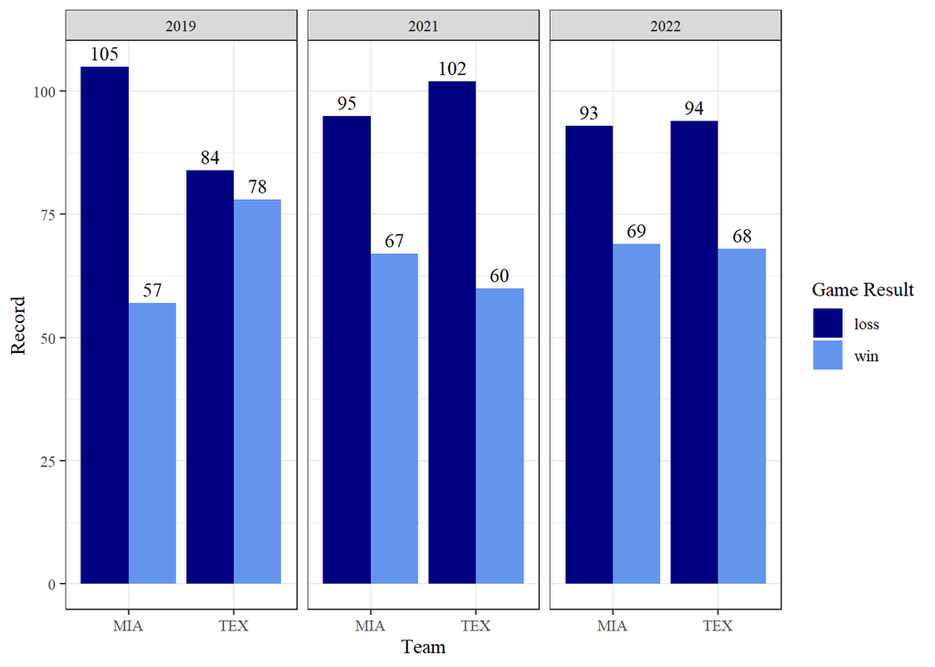

```r
win_loss <- data.frame(team = c("TEX", "TEX", "MIA", "MIA", "TEX", "TEX", "MIA","MIA", "TEX", "TEX", "MIA", "MIA"),
                       record = c(68, 94, 69, 93, 60, 102, 67, 95, 78, 84, 57, 105),
                       result = c("win", "loss", "win", "loss", "win", "loss","win", "loss","win", "loss", "win", "loss"),
                       season = c(2022, 2022, 2022, 2022, 2021, 2021, 2021, 2021, 2019, 2019, 2019, 2019))

win_loss %>%
  group_by(season) %>%
  ggplot(aes(x = factor(team), y = record, fill = result)) +
  geom_col(position = "dodge") +
  geom_text(aes(label = record), vjust = -.5, position = position_dodge(.9), family = "serif") +
  labs(x = "Team", y = "Record", fill = "Game Result") +
  #ylim(0, 110) +
  theme_bw() +
  scale_fill_manual(values = c("navyblue", "cornflowerblue")) +
  theme(text=element_text(family = "serif")) +
  facet_wrap(~season)
```

### Payroll

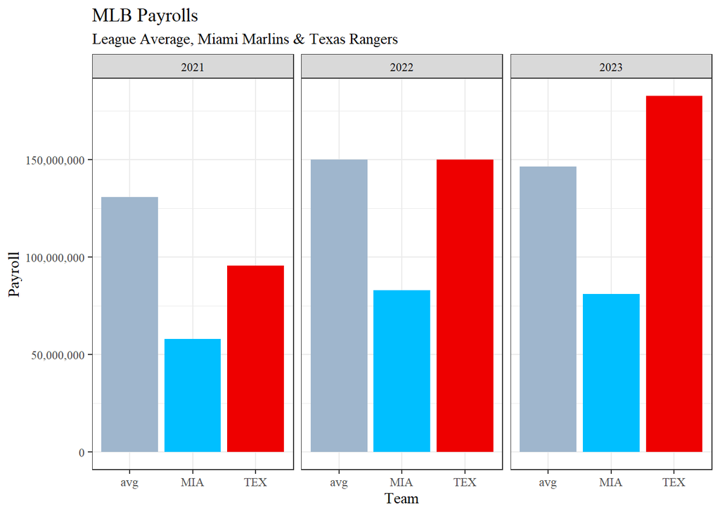

```r
payroll <- data.frame(team = c("TEX", "MIA", "avg", "TEX", "MIA", "avg", "TEX", "MIA", "avg"),
                      season = c(2021, 2021, 2021, 2022, 2022, 2022, 2023, 2023, 2023),
                      payroll = c(95788819, 58157900, 130886243, 150037446, 82954422, 149990188,
                                  182832500, 81075000, 146680879))
payroll %>%
  group_by(season) %>%
  ggplot(aes(x = factor(team), y = payroll, fill = team)) +
  geom_col(position = "dodge") +
  labs(title = "MLB Payrolls", subtitle = "League Average, Miami Marlins & Texas Rangers",
       x = "Team", y = "Payroll", color = "Team") +
  theme_bw() +
  scale_y_continuous(labels = scales::comma) +
  scale_fill_manual(values = c("slategray3", "deepskyblue", "red2")) +
  theme(text=element_text(family = "serif")) +
  theme(legend.position = "false") +
  facet_wrap(~season)
```

## Standings

### AL

**The first table is standings the day before the game of interest. The second is the standings on 9/12.**

```r
standings11_al <- bref_standings_on_date(date = "2022-09-11", division = "AL Overall")
standings12_al <- bref_standings_on_date(date = "2022-09-12", division = "AL Overall")

#bref_standings_on_date(date = "2022-09-11", division = "NL Overall")

# add row to show ranks
standings11_al <- standings11_al %>%
  mutate(rank = 1:15) %>%
  dplyr::select(rank, Tm:`pythW-L%`)
standings12_al <- standings12_al %>%
  mutate(rank = 1:15) %>%
  dplyr::select(rank, Tm:`pythW-L%`)

kable(standings11_al, caption = "AL - Day Before") %>%
  kable_styling("striped") %>%
  row_spec(12, background = "skyblue") %>%
  row_spec(5, background = "lavender") %>%
  row_spec(15, background = "gainsboro")
```

AL - Day Before

| rank | Tm | W | L | W-L% | GB | RS | RA | pythW-L% |
| --- | --- | --- | --- | --- | --- | --- | --- | --- |
| 1 | HOU | 90 | 50 | 0.643 | – | 632 | 458 | 0.643 |
| 2 | NYY | 85 | 56 | 0.603 | 5.5 | 697 | 491 | 0.655 |
| 3 | TBR | 78 | 60 | 0.565 | 11.0 | 586 | 521 | 0.554 |
| 4 | SEA | 79 | 61 | 0.564 | 11.0 | 589 | 523 | 0.554 |
| 5 | TOR | 78 | 61 | 0.561 | 11.5 | 653 | 586 | 0.549 |
| 6 | CLE | 73 | 65 | 0.529 | 16.0 | 575 | 548 | 0.522 |
| 7 | BAL | 73 | 67 | 0.521 | 17.0 | 583 | 582 | 0.501 |
| 8 | CHW | 72 | 69 | 0.511 | 18.5 | 613 | 624 | 0.492 |
| 9 | MIN | 69 | 70 | 0.496 | 20.5 | 605 | 592 | 0.510 |
| 10 | BOS | 69 | 72 | 0.489 | 21.5 | 644 | 677 | 0.477 |
| 11 | LAA | 61 | 79 | 0.436 | 29.0 | 537 | 588 | 0.459 |
| 12 | TEX | 60 | 79 | 0.432 | 29.5 | 619 | 633 | 0.490 |
| 13 | KCR | 57 | 84 | 0.404 | 33.5 | 553 | 710 | 0.388 |
| 14 | DET | 54 | 86 | 0.386 | 36.0 | 467 | 623 | 0.371 |
| 15 | OAK | 51 | 90 | 0.362 | 39.5 | 486 | 663 | 0.362 |

```r
kable(standings12_al, caption = "AL - On 9/12") %>%
  kable_styling("striped") %>%
  row_spec(11, background = "skyblue") %>%
  row_spec(3, background = "lavender") %>%
  row_spec(15, background = "gainsboro")
```

AL - On 9/12

| rank | Tm | W | L | W-L% | GB | RS | RA | pythW-L% |
| --- | --- | --- | --- | --- | --- | --- | --- | --- |
| 1 | HOU | 91 | 50 | 0.645 | – | 639 | 458 | 0.648 |
| 2 | NYY | 85 | 56 | 0.603 | 6.0 | 697 | 491 | 0.655 |
| 3 | TOR | 79 | 61 | 0.564 | 11.5 | 656 | 588 | 0.550 |
| 4 | SEA | 79 | 61 | 0.564 | 11.5 | 589 | 523 | 0.554 |
| 5 | TBR | 78 | 61 | 0.561 | 12.0 | 588 | 524 | 0.553 |
| 6 | CLE | 74 | 65 | 0.532 | 16.0 | 580 | 552 | 0.523 |
| 7 | BAL | 73 | 67 | 0.521 | 17.5 | 583 | 582 | 0.501 |
| 8 | CHW | 72 | 69 | 0.511 | 19.0 | 613 | 624 | 0.492 |
| 9 | MIN | 69 | 70 | 0.496 | 21.0 | 605 | 592 | 0.510 |
| 10 | BOS | 69 | 72 | 0.489 | 22.0 | 644 | 677 | 0.477 |
| 11 | TEX | 61 | 80 | 0.433 | 30.0 | 628 | 645 | 0.488 |
| 12 | LAA | 61 | 80 | 0.433 | 30.0 | 541 | 593 | 0.458 |
| 13 | KCR | 57 | 84 | 0.404 | 34.0 | 553 | 710 | 0.388 |
| 14 | DET | 54 | 87 | 0.383 | 37.0 | 467 | 630 | 0.366 |
| 15 | OAK | 51 | 90 | 0.362 | 40.0 | 486 | 663 | 0.362 |

Rangers went up 1 in the rankings. Toronto went up 2. Oakland stayed at 15.

### NL

**The first table is standings the day before the game of interest. The second is the standings on 9/12.**

```r
standings11_nl <- bref_standings_on_date(date = "2022-09-11", division = "NL Overall")
standings12_nl <- bref_standings_on_date(date = "2022-09-12", division = "NL Overall")

# add row to show ranks
standings11_nl <- standings11_nl %>%
  mutate(rank = 1:15) %>%
  dplyr::select(rank, Tm:`pythW-L%`)
standings12_nl <- standings12_nl %>%
  mutate(rank = 1:15) %>%
  dplyr::select(rank, Tm:`pythW-L%`)

kable(standings11_nl, caption = "AL - Day Before") %>%
  kable_styling("striped") %>%
  row_spec(12, background = "skyblue")
```

AL - Day Before

| rank | Tm | W | L | W-L% | GB | RS | RA | pythW-L% |
| --- | --- | --- | --- | --- | --- | --- | --- | --- |
| 1 | LAD | 96 | 43 | 0.691 | – | 756 | 446 | 0.724 |
| 2 | NYM | 89 | 52 | 0.631 | 8.0 | 666 | 526 | 0.606 |
| 3 | ATL | 87 | 53 | 0.621 | 9.5 | 697 | 538 | 0.616 |
| 4 | STL | 83 | 58 | 0.589 | 14.0 | 691 | 563 | 0.593 |
| 5 | PHI | 78 | 62 | 0.557 | 18.5 | 661 | 588 | 0.553 |
| 6 | SDP | 77 | 64 | 0.546 | 20.0 | 620 | 598 | 0.517 |
| 7 | MIL | 75 | 66 | 0.532 | 22.0 | 636 | 611 | 0.518 |
| 8 | SFG | 67 | 73 | 0.479 | 29.5 | 618 | 612 | 0.504 |
| 9 | ARI | 66 | 73 | 0.475 | 30.0 | 626 | 638 | 0.491 |
| 10 | COL | 61 | 80 | 0.433 | 36.0 | 635 | 770 | 0.413 |
| 11 | CHC | 58 | 82 | 0.414 | 38.5 | 568 | 673 | 0.423 |
| 12 | MIA | 57 | 82 | 0.410 | 39.0 | 494 | 598 | 0.413 |
| 13 | CIN | 56 | 82 | 0.406 | 39.5 | 594 | 701 | 0.425 |
| 14 | PIT | 51 | 88 | 0.367 | 45.0 | 492 | 706 | 0.341 |
| 15 | WSN | 49 | 92 | 0.348 | 48.0 | 545 | 751 | 0.357 |

```r
kable(standings12_nl, caption = "AL - On 9/12") %>%
  kable_styling("striped") %>%
  row_spec(12, background = "skyblue")
```

AL - On 9/12

| rank | Tm | W | L | W-L% | GB | RS | RA | pythW-L% |
| --- | --- | --- | --- | --- | --- | --- | --- | --- |
| 1 | LAD | 97 | 43 | 0.693 | – | 762 | 446 | 0.727 |
| 2 | NYM | 89 | 53 | 0.627 | 9.0 | 668 | 531 | 0.603 |
| 3 | ATL | 87 | 54 | 0.617 | 10.5 | 699 | 541 | 0.615 |
| 4 | STL | 83 | 58 | 0.589 | 14.5 | 691 | 563 | 0.593 |
| 5 | PHI | 78 | 62 | 0.557 | 19.0 | 661 | 588 | 0.553 |
| 6 | SDP | 77 | 64 | 0.546 | 20.5 | 620 | 598 | 0.517 |
| 7 | MIL | 75 | 66 | 0.532 | 22.5 | 636 | 611 | 0.518 |
| 8 | SFG | 68 | 73 | 0.482 | 29.5 | 621 | 614 | 0.505 |
| 9 | ARI | 66 | 74 | 0.471 | 31.0 | 626 | 644 | 0.487 |
| 10 | COL | 61 | 80 | 0.433 | 36.5 | 635 | 770 | 0.413 |
| 11 | CHC | 59 | 82 | 0.418 | 38.5 | 573 | 675 | 0.426 |
| 12 | MIA | 58 | 83 | 0.411 | 39.5 | 506 | 607 | 0.417 |
| 13 | CIN | 56 | 83 | 0.403 | 40.5 | 597 | 707 | 0.423 |
| 14 | PIT | 52 | 88 | 0.371 | 45.0 | 498 | 709 | 0.344 |
| 15 | WSN | 49 | 92 | 0.348 | 48.5 | 545 | 751 | 0.357 |

MIA stayed the same in the rankings

## Trevor Rogers

```r
rogers <- data.frame(count = c("0-1", "0-2", "1-0", "1-1", "1-2", "2-0", "2-1", "2-2", "3-0", "3-1", "3-2"),
                     `K/BB` = c(9.09, 66.0, 1.24, 3.04, 14.64, 0.54, 1.27, 4.54, 0.14, 0.36, 1.44),
                     OBP = c(.280, .190, .362, .312, .207, .515, .407, .277, .762, .620, .367))

rogers %>%
  kable(col.names = c("count", "K/BB", "OBP")) %>%
  kable_styling("striped")
```

| count | K/BB | OBP |
| --- | --- | --- |
| 0-1 | 9.09 | 0.280 |
| 0-2 | 66.00 | 0.190 |
| 1-0 | 1.24 | 0.362 |
| 1-1 | 3.04 | 0.312 |
| 1-2 | 14.64 | 0.207 |
| 2-0 | 0.54 | 0.515 |
| 2-1 | 1.27 | 0.407 |
| 2-2 | 4.54 | 0.277 |
| 3-0 | 0.14 | 0.762 |
| 3-1 | 0.36 | 0.620 |
| 3-2 | 1.44 | 0.367 |

66.0 is not a type, it’s really that high. I can re-format this table in any way you’d like just let me know how you want it to look.

I could make this into two separate bar graphs if you’d like. They can’t be on the same one since the scales are so different, and one of the K/BB values is much either than the others so it would make it hard to see all the values without using a transformation (like log).

## Postseason

```r
post2022 <- mlb_schedule_postseason(season = 2022) %>%
  dplyr::select(date:game_pk, game_type, season, official_date, description, teams_away_team_id, teams_away_team_name, teams_away_score, teams_home_team_id,
                teams_home_team_name, teams_home_score)
post2021 <- mlb_schedule_postseason(season = 2021) %>%
  dplyr::select(date:game_pk, game_type, season, official_date, description, teams_away_team_id, teams_away_team_name, teams_away_score, teams_home_team_id,
                teams_home_team_name, teams_home_score)
post2020 <- mlb_schedule_postseason(season = 2020) %>%
  dplyr::select(date:game_pk, game_type, season, official_date, description, teams_away_team_id, teams_away_team_name, teams_away_score, teams_home_team_id,
                teams_home_team_name, teams_home_score)
post2019 <- mlb_schedule_postseason(season = 2019) %>%
  dplyr::select(date:game_pk, game_type, season, official_date, description, teams_away_team_id, teams_away_team_name, teams_away_score, teams_home_team_id,
                teams_home_team_name, teams_home_score)
post2018 <- mlb_schedule_postseason(season = 2018) %>%
  dplyr::select(date:game_pk, game_type, season, official_date, description, teams_away_team_id, teams_away_team_name, teams_away_score, teams_home_team_id,
                teams_home_team_name, teams_home_score)
post5 <- rbind(post2022, post2021, post2020, post2019, post2018)
```

```r
# rangers
# post5 %>%
#   filter(teams_away_team_id == 140 | teams_home_team_id == 140) %>% View()
# # blue jays
# post5 %>%
#   filter(teams_away_team_id == 141 | teams_home_team_id == 141) %>% View()
```